# Reproducible Research: Peer Assessment 1

## Loading and preprocessing the data

1. Loading data with read.csv and unzip.

```r
data = read.csv(unzip(zipfile = "activity.zip"))
head(data)
```

```
##   steps       date interval
## 1    NA 2012-10-01        0
## 2    NA 2012-10-01        5
## 3    NA 2012-10-01       10
## 4    NA 2012-10-01       15
## 5    NA 2012-10-01       20
## 6    NA 2012-10-01       25
```

2. We convert data to data.table to help with data manipulation

```r
library(data.table)
DT = data.table(data)
```

## What is mean total number of steps taken per day?

```
## stat_bin: binwidth defaulted to range/30. Use 'binwidth = x' to adjust this.
```

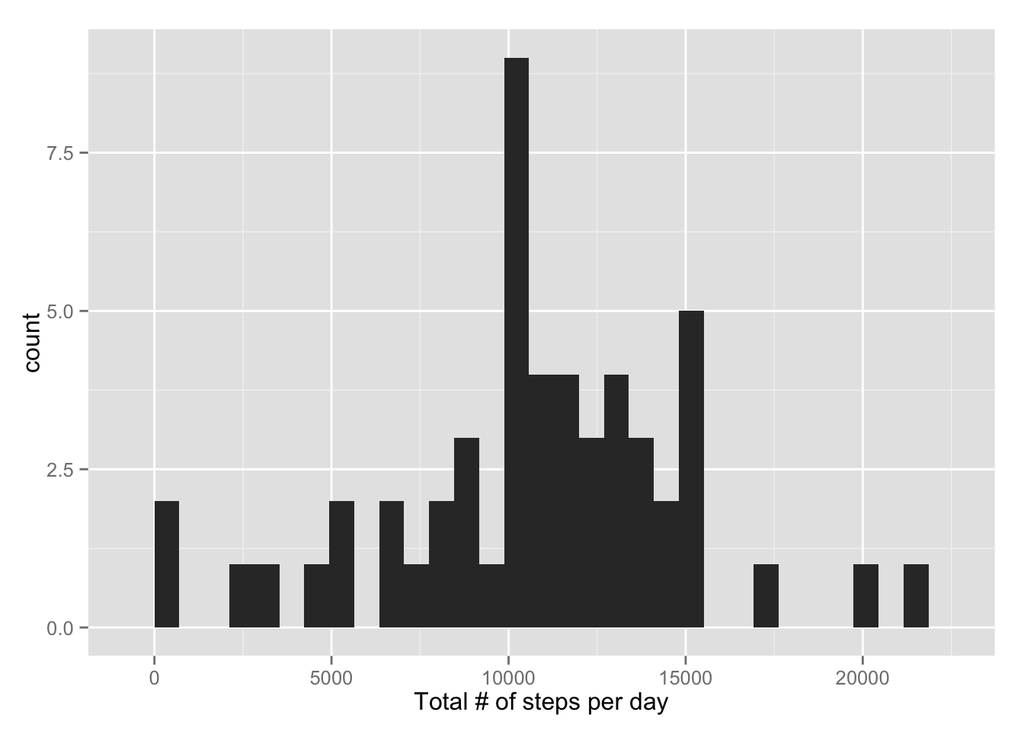

```r
library(ggplot2)
qplot(DT[ , sum(steps), by=date]$V1, xlab="Total # of steps per day")
```

```r
mean(DT[ , sum(steps), by=date]$V1, na.rm=TRUE)
```

```
## [1] 10766
```

```r
median(DT[ , sum(steps), by=date]$V1, na.rm=TRUE)
```

```
## [1] 10765
```

## What is the average daily activity pattern?

1. Time series plot 5-min interval (x-axis) against the average number of steps taken (across all days, y-axis).

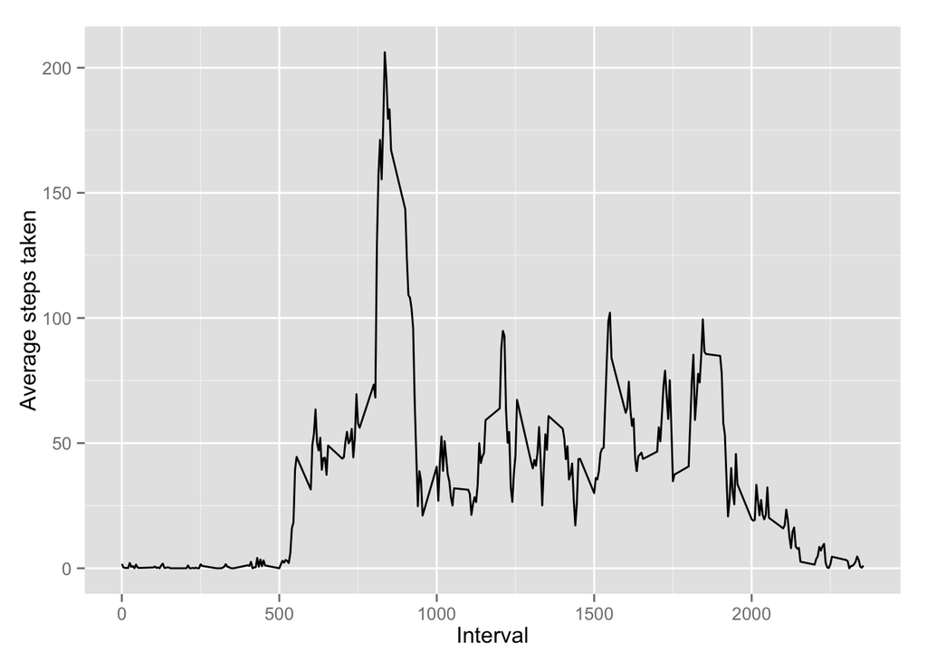

```r
qplot(unique(data$interval), DT[ , mean(steps, na.rm=T), by=interval]$V1, geom="line",
      xlab="Interval", ylab="Average steps taken")
```

2. The maximum number of steps taken during a 5-min interval, on average accross all the days in the dataset, is 206.1698, and it happens on interval number

```r
unique(data$interval)[which.max(DT[ , mean(steps, na.rm=T), by=interval]$V1)]
```

```
## [1] 835
```

## Imputing missing values

1. The total number of missing values in the dataset is

```r
length(which(is.na(data$steps)))
```

```
## [1] 2304
```

2. Imputing data, here we will fill NAs with the mean for the respective 5-min intervals.
3. The new data set is named ‘impData’

```r
aSpInt = DT[ , mean(steps, na.rm=T), by=interval]; impData = data
for (i in 1:nrow(impData)) {
  if (is.na(impData$steps[i])) {
      impData$steps[i] = aSpInt$V1[which(aSpInt$interval == impData$interval[i])]
    }
  }
head(impData)
```

```
##     steps       date interval
## 1 1.71698 2012-10-01        0
## 2 0.33962 2012-10-01        5
## 3 0.13208 2012-10-01       10
## 4 0.15094 2012-10-01       15
## 5 0.07547 2012-10-01       20
## 6 2.09434 2012-10-01       25
```

4. The histogram (of steps per day) now has peak at the mean of total number of steps taken per day. The mean is unchanged, and median is now equal to the mean (though the change is unsignificant). This is because (through quick visual inspection) NAs were not random, they occurred in each whole day (i.e., if a date contains an interval with NA, then all of its intervals are NA). By imputing data with means of interval across all days in the dataset, we are effectively filling these NA dates with the average number of steps taken per day (sum of averages = average of sums). We added over 86129 steps over 8 NA dates.

```
## stat_bin: binwidth defaulted to range/30. Use 'binwidth = x' to adjust this.
```

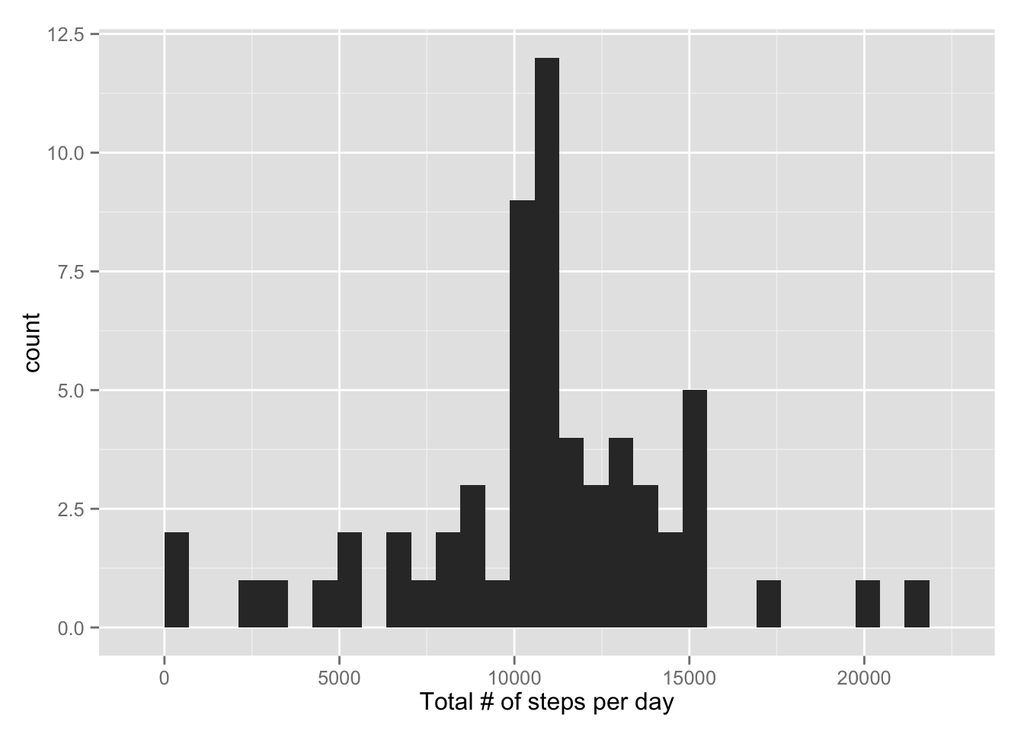

```r
iDT = data.table(impData)
qplot(iDT[ , sum(steps), by=date]$V1, xlab="Total # of steps per day")
```

```r
mean(iDT[ , sum(steps), by=date]$V1, na.rm=TRUE)
```

```
## [1] 10766
```

```r
median(iDT[ , sum(steps), by=date]$V1, na.rm=TRUE)
```

```
## [1] 10766
```

*Visual inspection

```r
head(cbind(DT[ , sum(steps), by=date]$V1, iDT[ , sum(steps), by=date]$V1))
```

```
##       [,1]  [,2]
## [1,]    NA 10766
## [2,]   126   126
## [3,] 11352 11352
## [4,] 12116 12116
## [5,] 13294 13294
## [6,] 15420 15420
```

## Are there differences in activity patterns between weekdays and weekends?

1. We create factor variable ‘day’ with two levels “weekday” and “weekend”.

```r
iDT[ , day:=factor(ifelse(weekdays(as.Date(date)) %in% c("Saturday", "Sunday"),"weekend", "weekday"))]
```

```
##          steps       date interval     day
##     1: 1.71698 2012-10-01        0 weekday
##     2: 0.33962 2012-10-01        5 weekday
##     3: 0.13208 2012-10-01       10 weekday
##     4: 0.15094 2012-10-01       15 weekday
##     5: 0.07547 2012-10-01       20 weekday
##    ---
## 17564: 4.69811 2012-11-30     2335 weekday
## 17565: 3.30189 2012-11-30     2340 weekday
## 17566: 0.64151 2012-11-30     2345 weekday
## 17567: 0.22642 2012-11-30     2350 weekday
## 17568: 1.07547 2012-11-30     2355 weekday
```

2. Average number of steps across all intervals on weekdays against weekends.

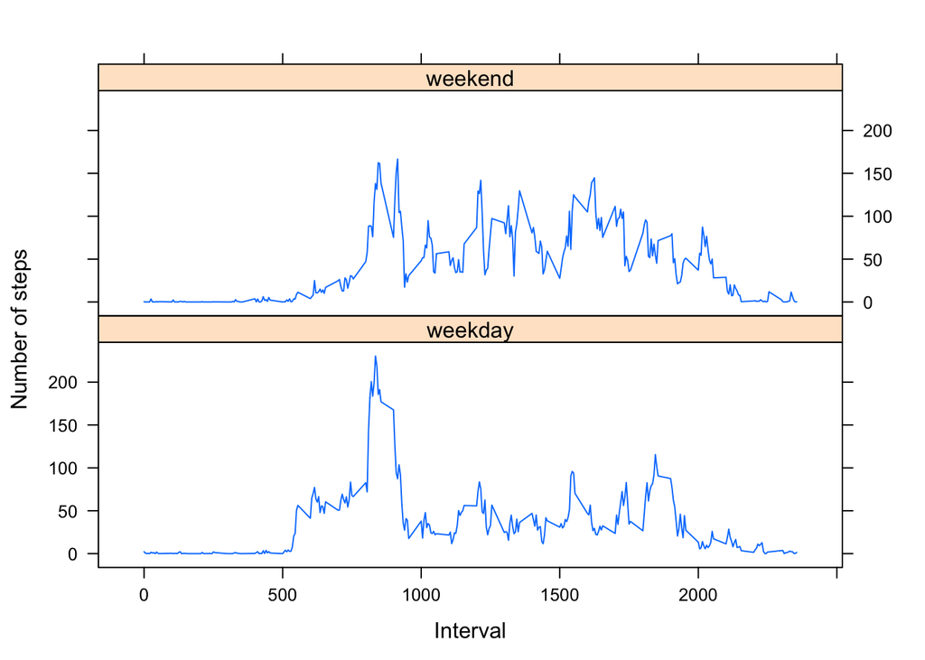

```r
library(lattice)
wdAvgs = iDT[day=="weekday", mean(steps), by=interval][ , day:="weekday"]
weAvgs = iDT[day=="weekend", mean(steps), by=interval][ , day:="weekend"]
Avgs = rbind(wdAvgs, weAvgs)
xyplot(V1 ~ interval | day, data=Avgs, type="l",layout=c(1, 2), ylab="Number of steps", xlab="Interval")
```